# Lab 3: Discrete Random Variables

## Part IV Matching distributions

### Assignment 4

In the file titled Samples2.csv there are three columns of data that come from three different distribution. the columns are labeled Sample_1, Sample_2, and Sample_3. They each contain data from different distributions. The three possible distributions are dU(0,20), Bin(50,.6), and Pois(10). Match each sample with the distribution it came from using histograms and descriptive statistics.

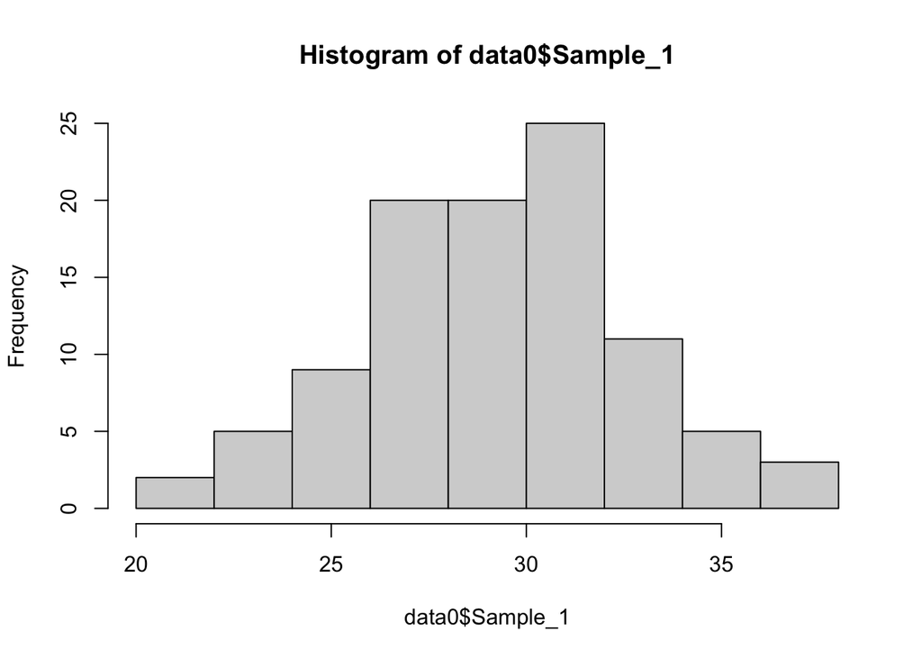

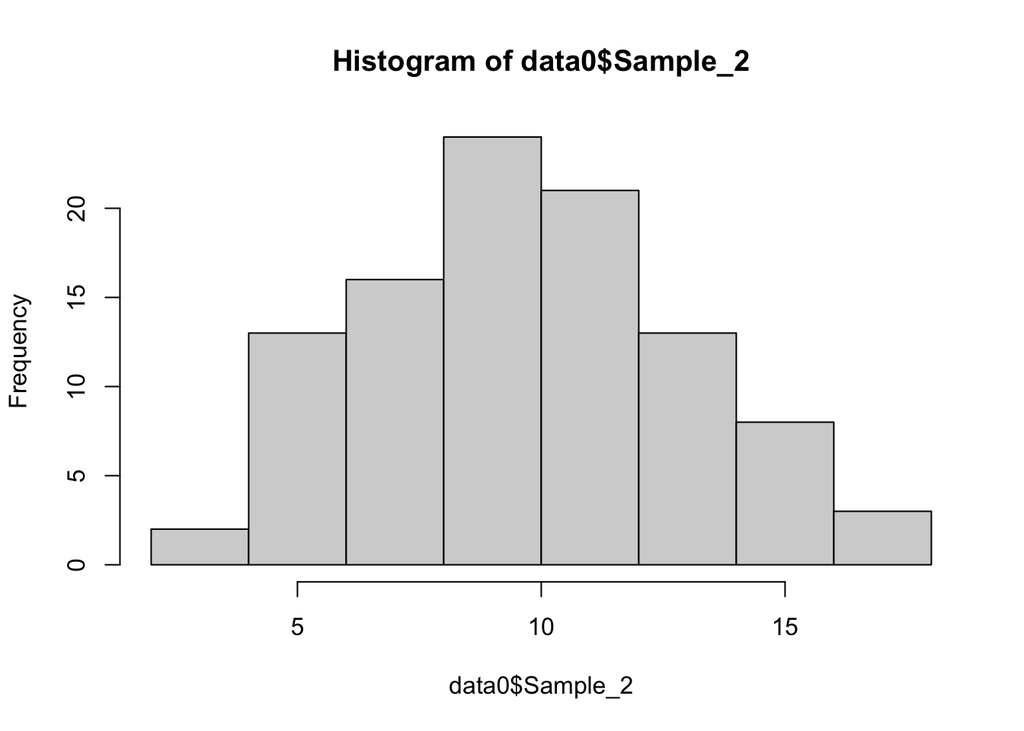

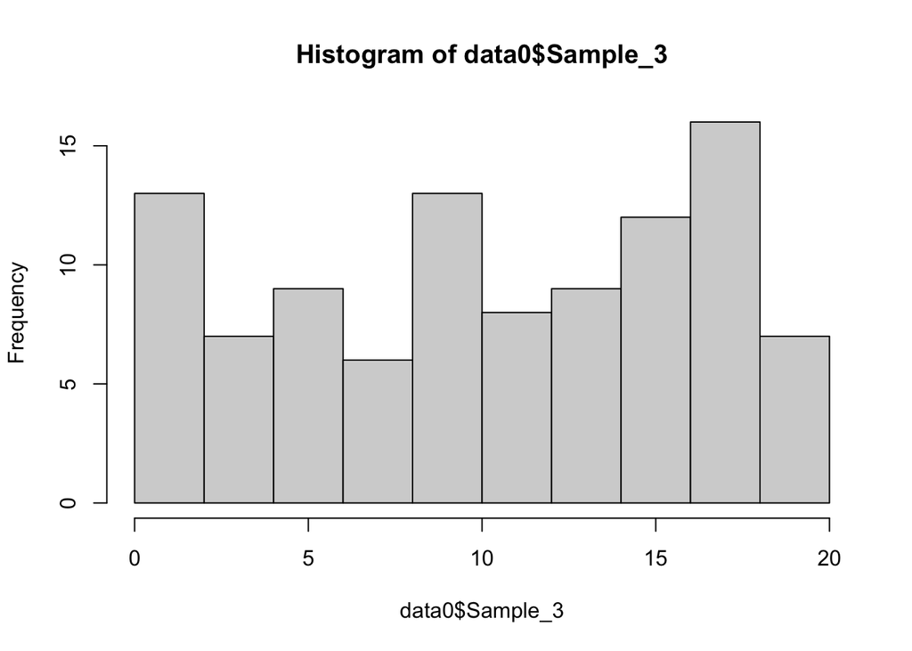

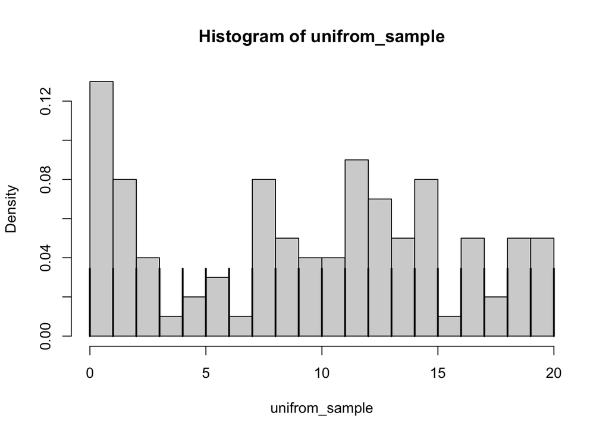

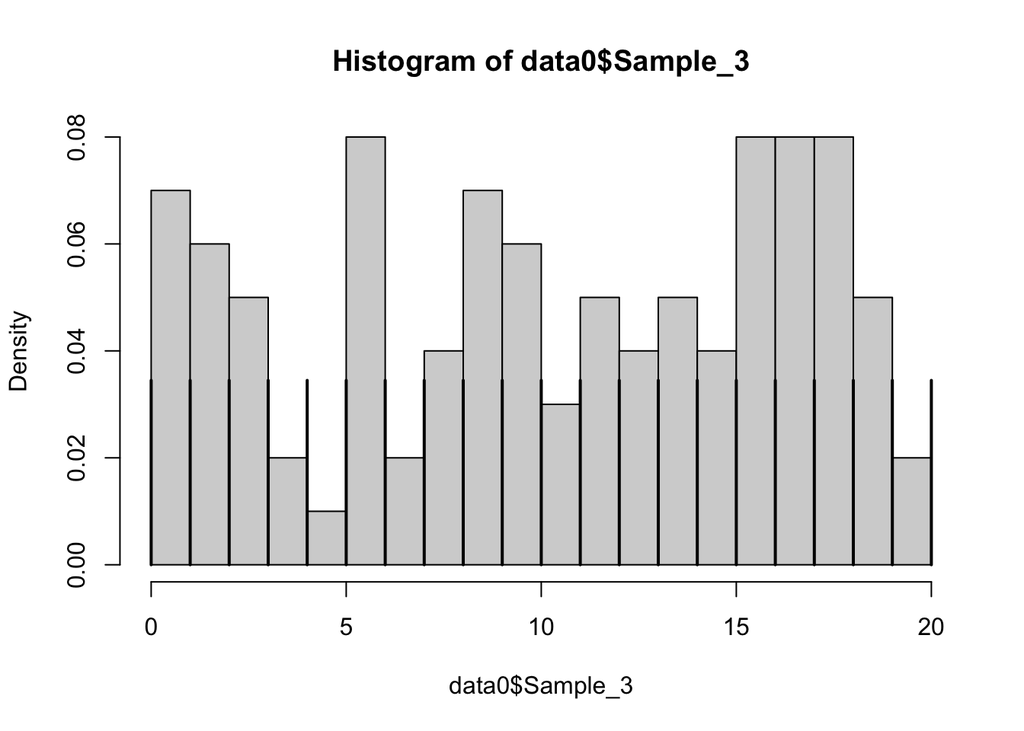

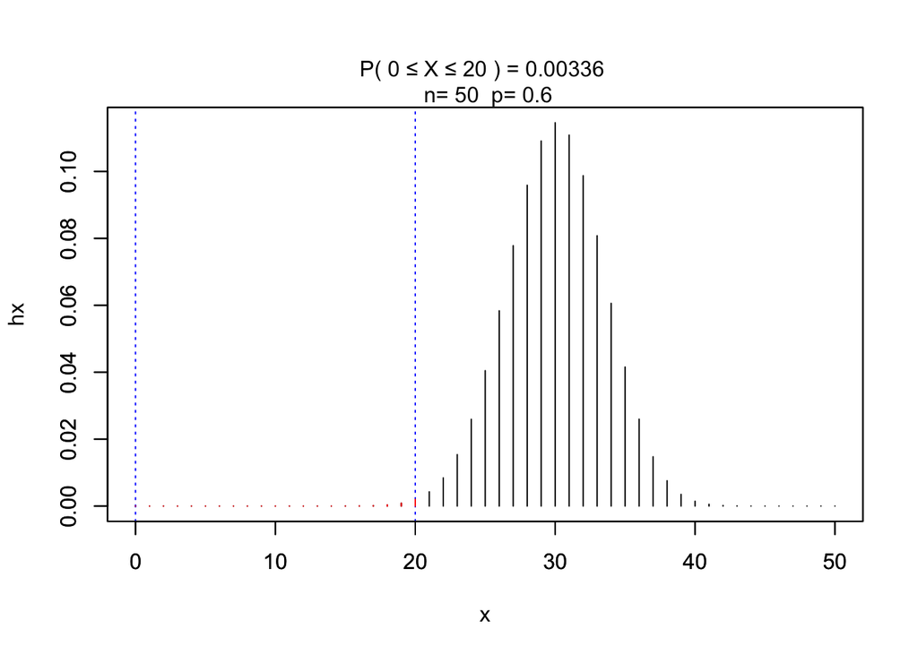

```
## [1] 0.7059883
```

```
dU(0,20) is related to sample 3, Bin(50, .6) is related to sample1, and Pois(10) is related to sample 2.
```

**End Assignment 4**